# Introduction

# Preparing dataframe

*Changing names*Merging dataframes

```python
#Changing country names to shorter names
lifeexp['Country'] = lifeexp['Country'].replace(['Venezuela (Bolivarian Republic of)'],'Venezuela')
lifeexp['Country'] = lifeexp['Country'].replace(['Bolivia (Plurinational State of)'],'Bolivia')
lifeexp['Country'] = lifeexp['Country'].replace(['Myanmar (Burma)'],'Myanmar')
lifeexp['Country'] = lifeexp['Country'].replace(['Syrian Arab Republic'],'Syria')
lifeexp['Country'] = lifeexp['Country'].replace(['The former Yugoslav republic of Macedonia'],'Macedonia')
lifeexp['Country'] = lifeexp['Country'].replace(['Viet Nam'],'Vietnam')
lifeexp['Country'] = lifeexp['Country'].replace(["(Federated States of) Monaco"],"Monaco")
lifeexp['Country'] = lifeexp['Country'].replace(["United Kingdom of Great Britain and Northern Ireland"],'United Kingdom')
#Replace status to 0 or 1
lifeexp['Status'] = lifeexp['Status'].replace(['Developing'],0)
lifeexp['Status'] = lifeexp['Status'].replace(['Developed'],1)
#column_values = lifeexp[["Country"]].values
#unique_values = np. unique(column_values)
#print(unique_values)
```

```python
#Using a module to import countries and continents
#create new variable called continent find mean values

import awoc
import pandas as pd

world = awoc.AWOC()

#Create the dataframe
df = pd.DataFrame(world.get_countries_list(), columns=['Country'])

continent = []
for r in df.iterrows():
        country = r[1]['Country']
        continent.append(world.get_country_data(country)['Continent Name'])

df['Continent']=continent
print(df)
```

```
                              Country      Continent
0                         Afghanistan           Asia
1                             Albania         Europe
2                             Algeria         Africa
3                      American Samoa        Oceania
4                             Andorra         Europe
5                              Angola         Africa
6                            Anguilla  North America
7                          Antarctica     Antarctica
8                 Antigua and Barbuda  North America
9                           Argentina  South America
10                            Armenia           Asia
11                              Aruba  North America
12                          Australia        Oceania
13                            Austria         Europe
```

[output cut: 226 more lines]

```python
#Replace names in awoc to match names in big data frame
df["Country"].replace({"Brunei":"Brunei Darussalam", "Tanzania":"United Republic of Tanzania","United States": "United States of America",
                        "Cabo Verde":"Cape Verde","Ivory Coast":"Côte d'Ivoire","Laos":"Lao Peoples Democratic Republic",
                        "Moldova":"Republic of Moldova","South Korea":"Republic of Korea", "North Korea":"Democratic People's Republic of Korea",
                        "East Timor":"Timor-Leste"},inplace =True)
print(df)
```

```
                                   Country      Continent
0                              Afghanistan           Asia
1                                  Albania         Europe
2                                  Algeria         Africa
3                           American Samoa        Oceania
4                                  Andorra         Europe
5                                   Angola         Africa
6                                 Anguilla  North America
7                               Antarctica     Antarctica
8                      Antigua and Barbuda  North America
9                                Argentina  South America
10                                 Armenia           Asia
11                                   Aruba  North America
12                               Australia        Oceania
13                                 Austria         Europe
```

[output cut: 226 more lines]

```python
#Merging old dataframe with new dataframe
#Added continent column with correct values

lifeexp_continent = pd.merge(lifeexp, df, on = 'Country', how = 'left')

lifeexp_continent.head(5)
lifeexp_continent.shape
#check if any nan values in continent
lifeexp_continent.columns[lifeexp_continent.isna().any()].tolist()
```

```
['Life expectancy ',
 'Adult Mortality',
 'Alcohol',
 'Hepatitis B',
 ' BMI ',
 'Polio',
 'Total expenditure',
 'Diphtheria ',
 'GDP',
 'Population',
 ' thinness  1-19 years',
 ' thinness 5-9 years',
 'Income composition of resources',
 'Schooling',
 'Continent']
```

```python
#removing rows where life expectancy has nan or no values
#removing rows where continent has nan or no values

lifeexp_continent= lifeexp_continent[lifeexp_continent['Life expectancy '].notnull()]
lifeexp_continent= lifeexp_continent[lifeexp_continent['Continent'].notnull()]
lifeexp_continent.shape

#replace nan values with mean of the value mising if nan values
lifeexp_continent['Adult Mortality'].fillna(value =lifeexp_continent['Adult Mortality'].mean (), inplace=True)
lifeexp_continent['infant deaths' ].fillna(value =lifeexp_continent['infant deaths' ].mean (), inplace=True)
lifeexp_continent['Alcohol'].fillna(value =lifeexp_continent['Alcohol'].mean (), inplace=True)
lifeexp_continent['percentage expenditure'].fillna(value =lifeexp_continent['percentage expenditure'].mean (), inplace=True)
lifeexp_continent['Hepatitis B'].fillna(value =lifeexp_continent['Hepatitis B'].mean (), inplace=True)
lifeexp_continent['Measles '].fillna(value =lifeexp_continent['Measles '].mean (), inplace=True)
lifeexp_continent[' BMI '].fillna(value =lifeexp_continent[' BMI '].mean (), inplace=True)
lifeexp_continent['under-five deaths '].fillna(value =lifeexp_continent['under-five deaths '].mean (), inplace=True)
lifeexp_continent['Polio'].fillna(value =lifeexp_continent['Polio'].mean (), inplace=True)
lifeexp_continent['Total expenditure'].fillna(value =lifeexp_continent['Total expenditure'].mean (), inplace=True)
lifeexp_continent['Diphtheria '].fillna(value =lifeexp_continent['Diphtheria '].mean (), inplace=True)
lifeexp_continent[' HIV/AIDS'].fillna(value =lifeexp_continent[' HIV/AIDS'].mean (), inplace=True)
lifeexp_continent['GDP'].fillna(value =lifeexp_continent['GDP'].mean (), inplace=True)
lifeexp_continent['Population'].fillna(value =lifeexp_continent['Population'].mean (), inplace=True)
lifeexp_continent[' thinness  1-19 years'].fillna(value =lifeexp_continent[' thinness  1-19 years'].mean (), inplace=True)
lifeexp_continent[' thinness 5-9 years'].fillna(value =lifeexp_continent[' thinness 5-9 years'].mean (), inplace=True)
lifeexp_continent['Income composition of resources'].fillna(value =lifeexp_continent['Income composition of resources'].mean (), inplace=True)
lifeexp_continent['Schooling'].fillna(value=lifeexp_continent['Schooling'].mean (), inplace=True)

#print(lifeexp_continent)

lifeexp_continent.info(verbose=True)
lifeexp_continent.columns[lifeexp_continent.isna().any()].tolist()
lifeexp_continent[lifeexp_continent.isnull().any(axis=1)]

#Checking that code worked
column_values = lifeexp_continent[["Country"]].values
#unique_values = np. unique(column_values)
#print(unique_values)
lifeexp_continent.isnull().values.any()
```

```
<class 'pandas.core.frame.DataFrame'>
Int64Index: 2816 entries, 0 to 2937
Data columns (total 23 columns):
 #   Column                           Non-Null Count  Dtype
---  ------                           --------------  -----
 0   Country                          2816 non-null   object
 1   Year                             2816 non-null   int64
 2   Status                           2816 non-null   int64
 3   Life expectancy                  2816 non-null   float64
 4   Adult Mortality                  2816 non-null   float64
 5   infant deaths                    2816 non-null   int64
 6   Alcohol                          2816 non-null   float64
 7   percentage expenditure           2816 non-null   float64
 8   Hepatitis B                      2816 non-null   float64
 9   Measles                          2816 non-null   int64
 10   BMI                             2816 non-null   float64
 11  under-five deaths                2816 non-null   int64
 12  Polio                            2816 non-null   float64
 13  Total expenditure                2816 non-null   float64
 14  Diphtheria                       2816 non-null   float64
 15   HIV/AIDS                        2816 non-null   float64
 16  GDP                              2816 non-null   float64
 17  Population                       2816 non-null   float64
 18   thinness  1-19 years            2816 non-null   float64
 19   thinness 5-9 years              2816 non-null   float64
 20  Income composition of resources  2816 non-null   float64
 21  Schooling                        2816 non-null   float64
 22  Continent                        2816 non-null   object
dtypes: float64(16), int64(5), object(2)
memory usage: 528.0+ KB
```

```
False
```

# Finding the means of of different variables that are grouped by continent.

```python
#group by continent
#find mean values of adult mortality
adult_mortality_continent=lifeexp_continent.groupby("Continent")['Adult Mortality'].mean()
print(adult_mortality_continent)
```

```
Continent
Africa           268.383413
Asia             133.555233
Europe            94.217105
North America    126.119048
Oceania          136.718750
South America    139.119792
Name: Adult Mortality, dtype: float64
```

Europe had the lowest adult mortality of all the continents. The highest adult mortality comes from Africa. All other continents have around the same mean.

```python
#group by continent
#find mean values of infant deaths.
infant_deaths_continent=lifeexp_continent.groupby("Continent")['infant deaths'].mean()
print(infant_deaths_continent)
```

```
Continent
Africa           45.796875
Asia             65.649709
Europe            0.768092
North America     5.654762
Oceania           1.400000
South America    11.489583
Name: infant deaths, dtype: float64
```

The continent with the lowest infant mortality rate is Europe followed by Oceania. The highest infant mortality rate is in Asia followed by Africa. When I filled the Nan's Oceania, Europe switched places.

```python
#group by continent
#find mean values of schooling
schooling_continent=lifeexp_continent.groupby("Continent")['Schooling'].mean()
print(schooling_continent)
```

```
Continent
Africa            9.353470
Asia             11.785601
Europe           15.029430
North America    12.407579
Oceania          13.009375
South America    13.406771
Name: Schooling, dtype: float64
```

The continent with the lowest amount of years in school is Africa. Europe has the highest number of years in school.

```python
#group by continent
#find mean values of population
population_continent=lifeexp_continent.groupby("Continent")['Population'].mean()
print(population_continent)
```

```
Continent
Africa           9.255994e+06
Asia             2.417497e+07
Europe           7.352355e+06
North America    7.991081e+06
Oceania          2.367619e+06
South America    1.763942e+07
Name: Population, dtype: float64
```

Asia and South America have the highest population of all the continents

```python
#group by continent
#find mean values of alcohol continent
alcohol_continent=lifeexp_continent.groupby("Continent")['Alcohol'].mean()
print(alcohol_continent)
```

```
Continent
Africa           2.802952
Asia             2.153467
Europe           9.137369
North America    6.001774
Oceania          2.895829
South America    5.708039
Name: Alcohol, dtype: float64
```

The continent that drinks the most is Europe and the continent that drinks the least is Asia.

# Using boxplots to visually see the data by using seaborn

How to use seaborn package-https://hippocampus-garden.com/pandas_boxplot/

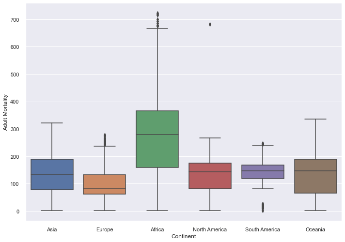

```python
#Summary of results
#box plots by continent and a given variable
sns.boxplot(x="Continent", y="Adult Mortality", data=lifeexp_continent)
```

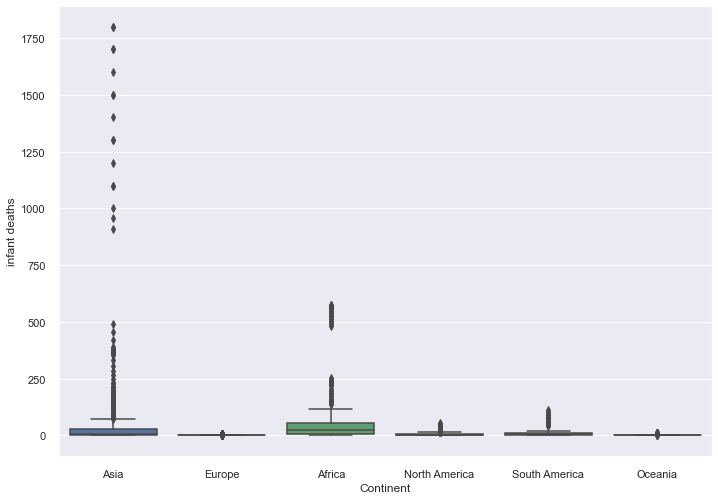

```python
#Boxplot of continent and infant deaths
sns.boxplot(x="Continent", y="infant deaths", data=lifeexp_continent)
```

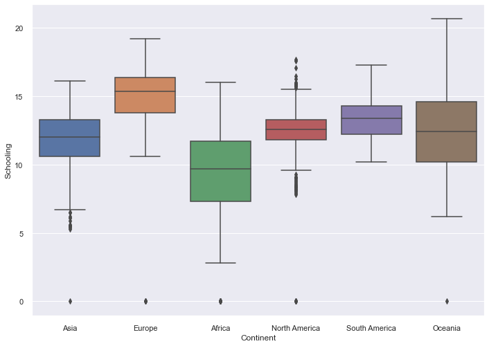

```python
#Boxplots of continent and schooling
sns.boxplot(x="Continent", y="Schooling", data=lifeexp_continent)
```

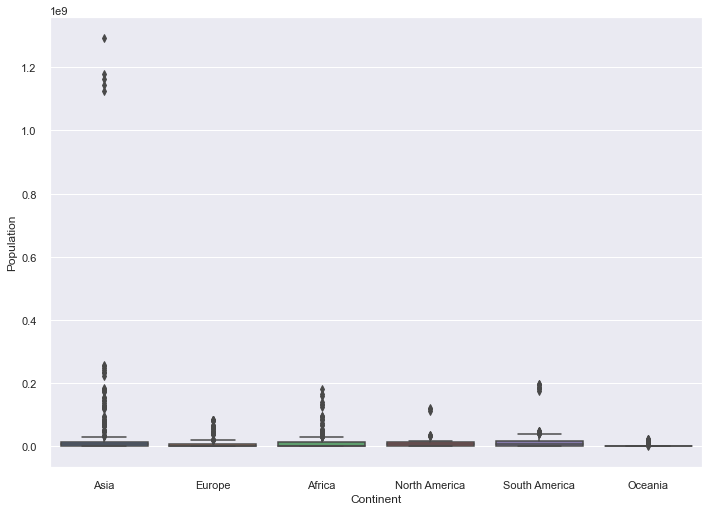

```python
#Boxplots of continents and population
sns.boxplot(x="Continent", y="Population", data=lifeexp_continent)
```

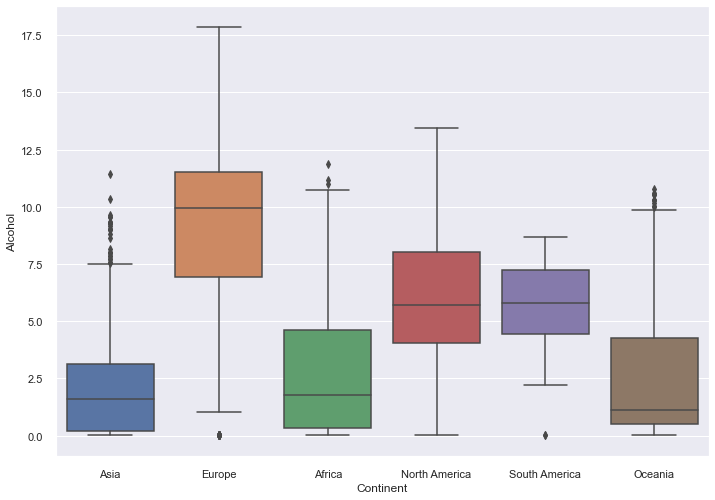

```python
#Boxplots of continents and alcohol
sns.boxplot(x="Continent", y="Alcohol", data=lifeexp_continent)
```